# Graphs and visualizations on the data

## Monthly Rat Sightings Before and After Rat Czar Office

### Data Loading

```r
# Load the rat sightings data
rat_data <- read_csv("data/rat_sightings.csv", show_col_types = FALSE)

# Converting 'Created Date' to datetime format
rat_data$Created_Date <- mdy_hms(rat_data$`Created Date`)

# Assuming the Rat Czar started office on April 12, 2023
rat_czar_start_date <- as.Date("2023-04-12")

# Filtering data for the period from one year before the Rat Czar started to the latest date in the dataset
one_year_before <- rat_czar_start_date - years(1)
latest_date <- max(rat_data$Created_Date)

data_after_one_year_before_rat_czar <- filter(rat_data, Created_Date >= one_year_before & Created_Date <= latest_date)

# Grouping by month and converting to Date format
data_after_one_year_before_rat_czar$Month <- as.Date(floor_date(data_after_one_year_before_rat_czar$Created_Date, "month"))
monthly_counts_after <- data_after_one_year_before_rat_czar %>%
  group_by(Month) %>%
  summarise(Count = n())
```

### Data Visualization

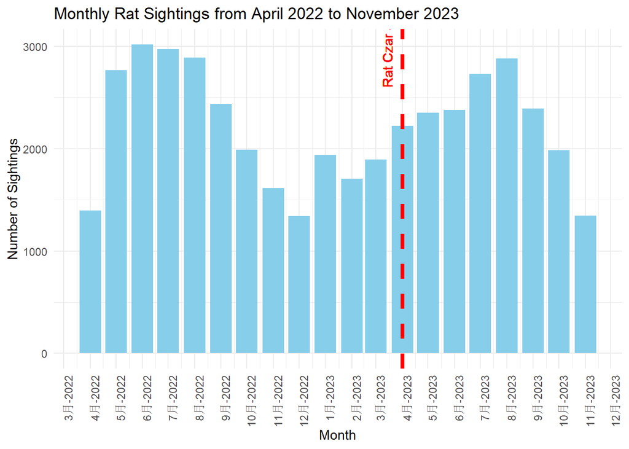

```r
# Plotting with ggplot2
rat_czar_start_month <- as.Date("2023-04-01") # The first day of the month when Rat Czar started

ggplot(monthly_counts_after, aes(x = Month, y = Count)) +
  geom_col(fill = "skyblue") +
  geom_vline(xintercept = as.numeric(rat_czar_start_month), linetype="dashed", color = "red", size=1.5) +
  geom_text(aes(x = rat_czar_start_month, y = max(monthly_counts_after$Count), label = "Rat Czar Start"),
            color = "red", vjust = -1, angle = 90, linewidth = 4) +
  scale_x_date(date_breaks = "1 month", date_labels = "%b-%Y") +
  labs(title = 'Monthly Rat Sightings from April 2022 to November 2023',
       x = 'Month',
       y = 'Number of Sightings') +
  theme_minimal() +
  theme(axis.text.x = element_text(angle = 90, hjust = 1))
```

### Interpretation of the Graph

The bar graph above illustrates the number of reported rat sightings from April 2022 to November 2023. The red dashed line marks the beginning of the Rat Czar’s term in April 2023.

A cursory glance at the graph suggests that there is variability in the number of sightings reported each month, which may be influenced by a variety of factors including seasonal changes and the urban environment. While there is no immediate drastic reduction in sightings following the appointment of the Rat Czar, this could imply that strategies employed require time to take effect, or that their impact is not instantly observable from this data alone.

## Rat Sightings Comparison by Borough Before and After Rat Czar Office

### Rat Sightings Comparison by Borough Before and After Rat Czar Office

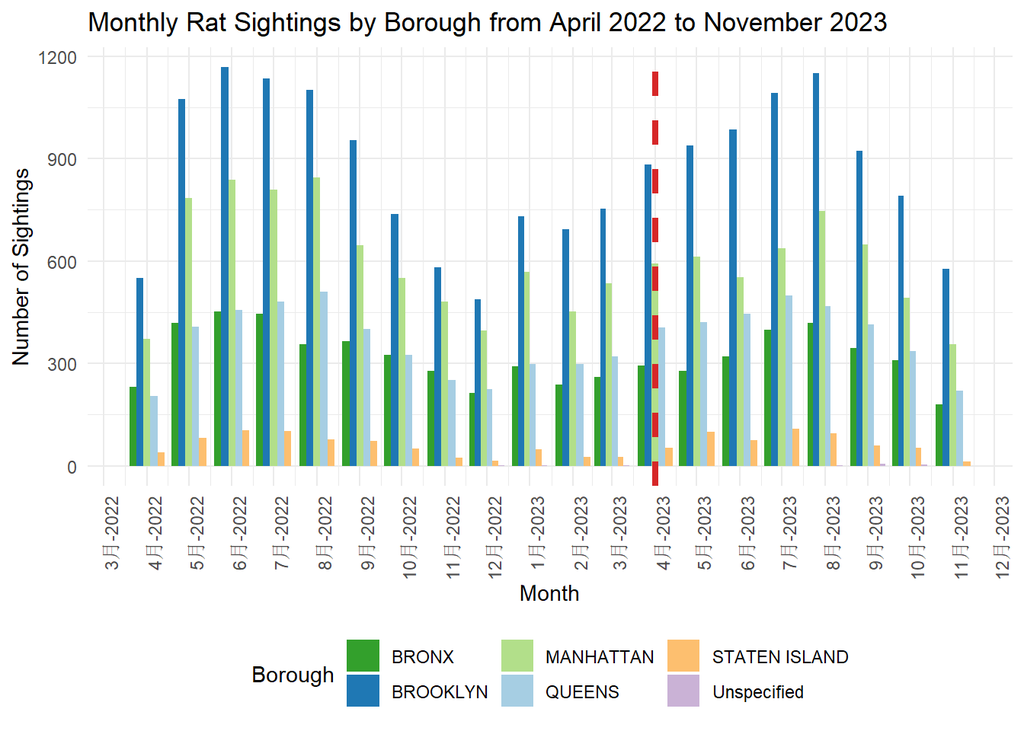

```r
# Assuming 'rat_data' has already been loaded and 'Created_Date' has been processed

# Grouping data by borough and month
sightings_by_borough_month <- rat_data %>%
  filter(Created_Date >= one_year_before & Created_Date <= latest_date) %>%
  mutate(Month = as.Date(floor_date(Created_Date, "month"))) %>%
  group_by(Borough, Month) %>%
  summarise(Count = n(), .groups = 'drop')


# Define a custom color palette without red for the boroughs
borough_colors <- c("BRONX" = "#33a02c", "BROOKLYN" = "#1f78b4", "MANHATTAN" = "#b2df8a",
                    "QUEENS" = "#a6cee3", "STATEN ISLAND" = "#fdbf6f", "Unspecified" = "#cab2d6")

# Plotting with ggplot2 using the custom color palette
ggplot(sightings_by_borough_month, aes(x = Month, y = Count, fill = Borough)) +
  geom_bar(stat = "identity", position = "dodge") +
  scale_fill_manual(values = borough_colors) + # Use the custom color palette
  geom_vline(xintercept = as.numeric(as.Date("2023-04-01")), linetype="dashed", color = "#d62728", size=1.5) + # Red line for Rat Czar start date
  scale_x_date(date_breaks = "1 month", date_labels = "%b-%Y") +
  labs(title = 'Monthly Rat Sightings by Borough from April 2022 to November 2023',
       x = 'Month',
       y = 'Number of Sightings',
       fill = 'Borough') +
  theme_minimal() +
  theme(axis.text.x = element_text(angle = 90, hjust = 1)) +
  theme(legend.position = "bottom")
```

### Interpretation of the Graph

The graph displays monthly rat sightings by borough in New York City from April 2022 to November 2023. Each borough is represented by a different color, with an additional category for unspecified locations. A red dashed line denotes April 2023, when the Rat Czar commenced their role.

Interpreting the graph, we can observe that sightings fluctuate monthly, with peaks and troughs that may be influenced by various factors, such as changes in weather or waste management practices. After the red line, indicating the Rat Czar’s start date, there is no immediate and drastic change in the trend of sightings for any borough. This could suggest that any measures implemented by the Rat Czar may take time to show significant effects.

Additionally, it’s noticeable that certain boroughs, such as Brooklyn and Manhattan, consistently report higher numbers of sightings. The graph also shows that some months exhibit a higher number of sightings across all boroughs, which might indicate seasonal patterns in rat activity or reporting.

Lastly, the unspecified category indicates reports that did not have a borough listed. The presence of this category suggests that data collection or reporting may have inconsistencies, which could affect the analysis.

Overall, while the Rat Czar’s impact isn’t immediately discernible from the graph, ongoing analysis with more data over time will be essential to understand the full effect of the initiatives taken to control the rat population.

## Rat Sightings and Covid-19

The COVID-19 pandemic brought unprecedented challenges to urban management and public health. In New York City, changes in human activity during the pandemic may have influenced rat behavior and sightings. This section analyzes the rat sightings data to observe potential shifts in rat populations across the city’s boroughs during the pre-pandemic, pandemic, and post-pandemic periods.

### General Analysis

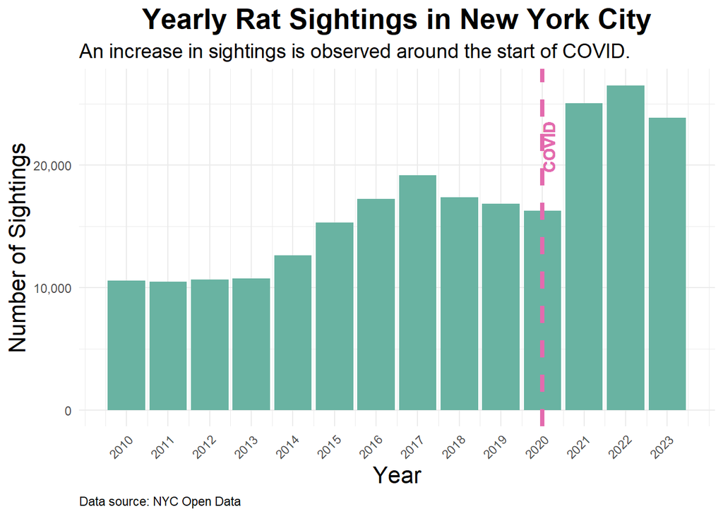

```r
rat_data$Year <- year(rat_data$Created_Date)
# Aggregate the number of sightings per year
yearly_sightings <- rat_data %>%
  group_by(Year) %>%
  summarise(Count = n(), .groups = 'drop')

# The data must be ungrouped before plotting in some ggplot2 versions
yearly_sightings <- ungroup(yearly_sightings)

# Plotting the number of rat sightings per year with enhancements
max_count <- max(yearly_sightings$Count)
ggplot(yearly_sightings, aes(x = Year, y = Count)) +
  geom_col(fill = "#69b3a2") +
  geom_vline(xintercept = 2020, linetype="dashed", color = "#e36bae", size=1.5) +
  geom_text(aes(x = 2020, y = max_count - 5000, label = "COVID"),  # Adjust position here
            color = "#e36bae", vjust = 1, angle = 90, size = 4, fontface = "bold") +
  scale_x_continuous(breaks = yearly_sightings$Year, labels = scales::label_wrap(5)) +
  scale_y_continuous(labels = scales::comma) +
  labs(title = 'Yearly Rat Sightings in New York City',
       subtitle = "An increase in sightings is observed around the start of COVID.",
       x = 'Year',
       y = 'Number of Sightings',
       caption = "Data source: NYC Open Data") +
  theme_minimal() +
  theme(
    plot.title = element_text(size = 20, face = "bold", hjust = 0.5),
    plot.subtitle = element_text(size = 14),
    axis.text.x = element_text(angle = 45, vjust = 1, hjust=1),
    axis.title = element_text(size = 16),
    legend.position = "none",
    plot.caption = element_text(hjust = 0, vjust = 1)
  )
```

### Interpretation of the Yearly Rat Sightings Graph

Subsequent years, 2021 and 2022, maintain a higher level of sightings compared to the pre-pandemic years, indicating that the factors contributing to increased sightings may have persisted beyond the initial pandemic phase. The data for 2023 shows a continued prevalence of rat sightings, suggesting that the conditions favorable to rat visibility or population growth are still present.

However, without further analysis, we cannot conclusively attribute changes in rat sighting trends solely to the pandemic. Other environmental, social, or data collection factors might also play a role. Ongoing monitoring and analysis would be necessary to understand the full range of influences on rat sightings in New York City.

### Daily Rat Sightings Comparison

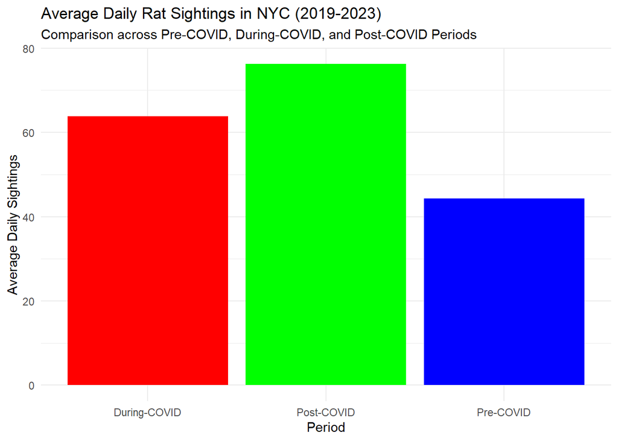

```r
# Define the pandemic period and the post-pandemic start
pandemic_start <- as.Date("2020-03-11")
post_pandemic_start <- as.Date("2023-05-05")

# Filter the data for the analysis period (2019-2023)
analysis_data <- rat_data %>%
  filter(Year >= 2019) %>%
  mutate(Period = case_when(
    Created_Date < pandemic_start ~ "Pre-COVID",
    Created_Date >= pandemic_start & Created_Date < post_pandemic_start ~ "During-COVID",
    Created_Date >= post_pandemic_start ~ "Post-COVID"
  ))

# Calculate the daily sightings for each period
daily_sightings <- analysis_data %>%
  count(Period, Date = as.Date(Created_Date)) %>%
  group_by(Period) %>%
  summarise(Avg_Daily_Sightings = mean(n), .groups = 'drop')

# Plot the average daily sightings for each period
ggplot(daily_sightings, aes(x = Period, y = Avg_Daily_Sightings, fill = Period)) +
  geom_bar(stat = "identity") +
  scale_fill_manual(values = c("Pre-COVID" = "blue", "During-COVID" = "red", "Post-COVID" = "green")) +
  labs(title = 'Average Daily Rat Sightings in NYC (2019-2023)',
       subtitle = "Comparison across Pre-COVID, During-COVID, and Post-COVID Periods",
       x = 'Period',
       y = 'Average Daily Sightings') +
  theme_minimal() +
  theme(legend.position = "none")
```

### Interpretation of the Average Daily Rat Sightings Graph

Interestingly, the “Post-COVID” period, represented by the green bar, shows a continuation of higher average sightings compared to the “Pre-COVID” period (blue bar). This suggests that the conditions leading to increased sightings during the pandemic may have persisted or that the rat population has been lastingly impacted by the pandemic’s effects.

The data indicates that the pandemic may have had a significant and enduring impact on rat sighting dynamics in the city, warranting further investigation into urban wildlife patterns and public health implications in the post-pandemic era.

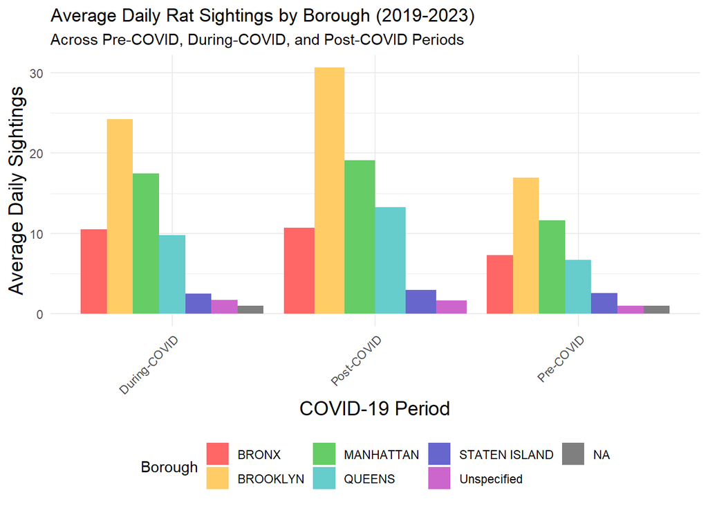

```r
# Grouping data by borough, period, and date, then calculating the average daily sightings
borough_period_sightings <- analysis_data %>%
  group_by(Borough, Period, Date = as.Date(Created_Date)) %>%
  summarise(Daily_Count = n(), .groups = 'drop') %>%
  group_by(Borough, Period) %>%
  summarise(Avg_Daily_Sightings = mean(Daily_Count), .groups = 'drop')

# Define a color palette
colors <- c("#FF6666", "#FFCC66", "#66CC66", "#66CCCC", "#6666CC", "#CC66CC", "#000000")

# Assign colors to boroughs
borough_colors <- setNames(colors, unique(borough_period_sightings$Borough))

# Plot with the selected color palette
ggplot(borough_period_sightings, aes(x = Period, y = Avg_Daily_Sightings, fill = Borough)) +
  geom_bar(stat = "identity", position = "dodge") +
  scale_fill_manual(values = borough_colors) +
  theme_minimal() +
  theme(
    axis.text.x = element_text(angle = 45, vjust = 1, hjust=1),
    axis.title = element_text(size = 14),
    legend.position = "bottom"
  ) +
  labs(
    title = 'Average Daily Rat Sightings by Borough (2019-2023)',
    subtitle = "Across Pre-COVID, During-COVID, and Post-COVID Periods",
    x = 'COVID-19 Period',
    y = 'Average Daily Sightings',
    fill = 'Borough'
  )
```

### Interpretation of the Average Daily Rat Sightings by Borough

The bar chart compares average daily rat sightings in New York City by borough, across three different periods: Pre-COVID, During-COVID, and Post-COVID. Each borough is distinctly colored, allowing for an easy visual comparison.

This visual analysis underscores the impact of the COVID-19 pandemic on rat sightings in New York City, particularly in Brooklyn. It also prompts further investigation into the enduring effects of the pandemic on urban wildlife and the efficacy of control measures post-pandemic.

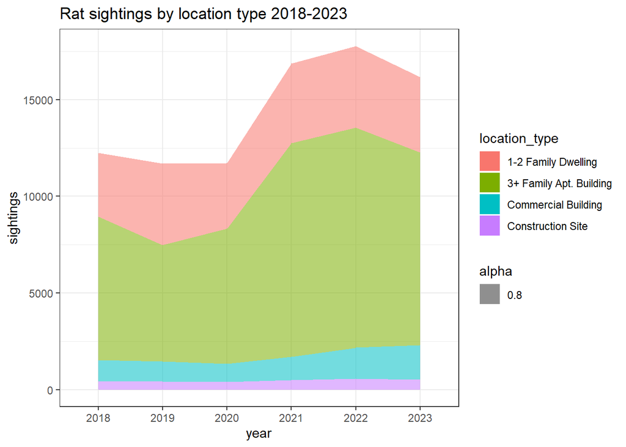

```r
rats_df =
  read_csv("./data/rat_sightings.csv", show_col_types = FALSE) %>%
  janitor::clean_names() %>%
  select(unique_key, created_date, location_type, incident_zip, city, borough, latitude, longitude, location) %>%
  separate(created_date, into = c("created_date", "time", "am_pm"), sep = " ") %>%
  separate(created_date, into = c("month", "day", "year"), sep = "/")

loc_df =
  rats_df %>%
    filter(year == "2018" | year == "2019" | year == "2020" | year == "2021" | year == "2022" | year == "2023") %>%
    select(year, location_type) %>%
    group_by(year, location_type) %>%
    summarize(sightings = n()) %>%
    arrange(desc(sightings)) %>%
    filter(location_type == "3+ Family Apt. Building" | location_type == "1-2 Family Dwelling" | location_type == "Commercial Building" | location_type == "Construction Site")

loc_df %>%
  ggplot(aes(x = year, y = sightings, fill = location_type)) +
  geom_area(aes(group = location_type, alpha = 0.8)) +
  theme_bw() +
  labs(title = "Rat sightings by location type 2018-2023")
```